# Limited Liability Company Real Estate Owners in Philadelphia

Kathryn Hurchla

December 15, 2020

```r
?render()
library("knitr")
?knitr
?knit2html
# knit2html(  # Error: It seems you should call rmarkdown::render() instead of knitr::knit2html() because Kathryn_Hurchla_final_project_RE_LLC_Slidy.Rmd appears to be an R Markdown v2 document.(surprised because my RStudio version when I ran this was 1.3.1093)
rmarkdown::render(
  "Kathryn_Hurchla_final_project_RE_LLC_Slidy.Rmd",
  output_format = 'html_document')
```

```
##
##
## processing file: Kathryn_Hurchla_final_project_RE_LLC_Slidy.Rmd
```

[output not shown]

## Introduction

Introduction: Although Pennsylvania is not one of the seven US states which offer the establishment of a unique kind of Series LLC, many real estate investors and entrepreneurs use a similar multi-level LLC ownership structure for asset protection, where multiple LLC act as Subsidiaries of a primary holding or operating LLC.

In Pennsylvania, an LLC or other business organization may have ownership of another LLC. Thereby the circumstance for multi-level LLC structures may be registered with the state which is the governing body for business organization. Project focuses on PA organization and Philadelphia Real Estate records.

Objectives

1. Measure to what degree the perceived asset protection is demonstrated as real by analyzing public data available. Test a hypothesis that an LLC is less likely to incur a claim of negligence than an individual property owner.
2. Test a hypothesis that an LLC, as a property buyer, is more likely to pay below market value, i.e. market rate, as compared to another type of buyer such as an individual or non-LLC partnership.

## Environment

```r
getwd()
```

```
## [1] "/Users/kathrynhurchla/Documents/AAA_MICA_DAV_Statistics/Kathryn_Hurchla_final_project_RE_LLC"
```

```r
#install.packages("DBI")
#install.packages("readr")
#install.packages("modelr")
#install.packages("filesstrings")
#install.packages("scales")
#install.packages("gridExtra")
#install.packages("grid")
#install.packages("contriburl")
library(filesstrings)
library(DBI)
library(tidyverse)
```

```r
library(stringr)
library(readr)
library(dplyr)
library(modelr)
library(ggplot2)
library(scales)
library(gridExtra)
library(gridExtra)
library(grid)
library(rmarkdown)
```

## Data

Public data which is available through Open Data Philly and state or city judicial repositories will be used. CSV or HTML files are available, and due to the large size of some of these datasets, I may attempt to access them through the API available if time permits. I compiled judicial data search results into structured file formats for analysis.

### LLC ownership of other LLC

Although ownership is collected upon registration in a structured way, there does not seem to be a dataset containing Owner Names available, nor are the certification attachments available that may contain partial ownership information. Only a push search web application is available to search by known owner name one by one for this unfortunately, where I may be able to run a wildcard search as with deeds and claims.

Possibly I could try to tie them through address matching from datasets below. Currently it requires a Right to Know public access request to find out the owners listed on a LLC’s certificate of organization records with the State of PA. LLC ownership is not generally found publicly because of the limited financial reporting required of this organization structure, e.g. by the IRS which only requires certain public filings by certain tax entities, such as not for profit organizations or corporations meeting certain stock/securities criteria. Therefore tax and financial reports are not publicly accessible for the majority of LLC orgs.

```r
# Commenting out code because I was unable to source data on LLC Ownership
# Use source() or read_csv()

# Write file to a named variable
# LLC <-

# summary(LLC)

# Identify and name organizations which are a Parent Company LLC
# LLC_parent <-

# summary(LLC_parent)

# Identify and name organizations which are a Subsidiary LLC of another Parent Company LLC
# LLC_subsidiary <-

# summary(LLC_subsidiary)
```

### Real Estate ownership by LLC

Deed transactions 1999+ are included in table form https://www.opendataphilly.org/dataset/real-estate-transfers where grantors or grantees contains LLC (which is required as part of legal name on contracts) Entity type “Limited Liability Corporation” is not in this dataset but appears in some other city records, so is either linked from another source or is calculated in some website form views. There is a Google group and metadata documentation for questions with opendataphilly datasets.

Filter out mortgage or other unrelated document type transactions (use separately for alternate analysis of LTV). This filtering was done at the API call level with the SQL code to source only Deed Type = “DEED”. In Pennsylvania, the legal name of an LLC is required to contain a designator e.g., “company,” “limited” or “limited liability company” or any abbreviation thereof such as “LLC”, “L.L.C”, so I can identify owners by this assuming they have listed their full legal LLC org name in title transfer of real estate, i.e. and not a Dba doing business as name or truncating that ending for general use purposes. Such designators generally appear at the end of LLC org names which may simplify the character search.

May be able to get some or all of the Legal Entity Type (LLC) by linking with this dataset, although I would prefer to use articles or LLC incorporation registration as more complete set over this which is Commercial Activity License data (An legit LLC in Philadelphia requires both under most circumstances) https://www.opendataphilly.org/dataset/licenses-and-inspections-commercial-activity-licenses LEGALENTITYTYPE REVENUECODE field will indicate one of a variety of related real estate business codes (although any LLC may own real estate)

In order to source this very large dataset using an API, I queried it outside R Markdown through HTTPS via Carto’s SQL API, passing SQL queries as the q parameter (PostgreSQL). Note also these files exceed the maximum 25MB size for hosting in my GitHub repository; from the API pull I wrote the file to my local machine for analysis.

You are recommended to repeat the SQL code to download your own file for analysis with the subsequent R scripts. Move it to a “files” folder in your working directory, i.e. “files/RTT_Summary_Deeds.csv” (I’m inserting R code you may use to do this step below). For reference Google Chrome omnibox address bar was used to access API. No API Key is required using this public connection for only read access to the data. Alternately, you may try using the R dplyr function read_csv() directly with the connection script beginning with https below in place of the file argument (I opted not to do so because documentation states that R automatically downloads file regardless with files starting with http://, https://, ftp://, or ftps://)–Let me know how it goes if you try.

```r
# Install the latest odbc release from CRAN:
#install.packages("odbc")

# Or the the development version from GitHub:
# install.packages(devtools)
#devtools::install_github("rstats-db/odbc")

library(odbc)

con <- DBI::dbConnect(odbc::odbc(),
  driver = "PostgreSQL Driver",
  database = "PostgreSQL",
  UID    = rstudioapi::askForPassword("Database user"),
  PWD    = rstudioapi::askForPassword("Database password"),
  host = "localhost",
  port = 5432)
```

```
## Error: nanodbc/nanodbc.cpp:1021: 00000: FATAL:  role "postgresql" does not exist
##
```

```r
odbc::odbcListDrivers()
knit_engines$set()

?DBI
odbc::odbcListDataSources()
```

```sql
## Postgre SQL
# Test API connection by running a simple query to view count of all observations in your browser window:
https://phl.carto.com/api/v2/sql?q=SELECT count(*) FROM RTT_SUMMARY

## Query and output CSV files by date range, e.g. from 2017-2028 below.
# This worked but the large size of some of the date ranges such as 2016-2017 and 2018-2019 which incurred problems downloading the files during the middle of the day:
# https://phl.carto.com/api/v2/sql?filename=RTT_SUMMARY&format=csv&skipfields=cartodb_id,the_geom,the_geom_webmercator&q=SELECT%20*,%20ST_Y(the_geom)%20AS%20lat,%20ST_X(the_geom)%20AS%20lng%20FROM%20RTT_SUMMARY%20WHERE%20display_date%20%3E=%20%272018-01-01%27%20AND%20display_date%20%3C%20%272020-01-01%27


## More effectively, I pulled only the deeds, and output it to a single CSV file as RTT_Summary_Deeds to be named a variable as 'deeds';
# this filtering limited the size of the file which also allowed me to include most of the variables as columns to explore.

# https://phl.carto.com/api/v2/sql?filename=RTT_SUMMARY&format=csv&skipfields=cartodb_id,the_geom,the_geom_webmercator&q=SELECT *, ST_Y(the_geom) AS lat, ST_X(the_geom) AS lng FROM RTT_SUMMARY WHERE document_type = 'DEED'
https://phl.carto.com/api/v2/sql?filename=RTT_SUMMARY&format=csv&skipfields=cartodb_id,the_geom,the_geom_webmercator&q=SELECT%20*,%20ST_Y(the_geom)%20AS%20lat,%20ST_X(the_geom)%20AS%20lng%20FROM%20RTT_SUMMARY%20WHERE%20document_type%20=%20'DEED'

# When attempting to directly filter for LLC ownership through the API connection, I was receiving an error at the like wildcard operator when running the LLC criteria in HTTPS.
# {"error":["syntax error at or near \"%\""]}
# https://phl.carto.com/api/v2/sql?q=SELECT document_id, display_date, zip_code, grantors, grantees, recording_date, opa_account_num, property_count FROM RTT_SUMMARY WHERE document_type = 'DEED' AND grantees NOT LIKE '%LLC%'
# https://phl.carto.com/api/v2/sql?filename=deeds_llc.csv&q=SELECT document_id, display_date, zip_code, grantors, grantees, recording_date, opa_account_num, property_count FROM RTT_SUMMARY WHERE document_type = 'DEED' AND grantees LIKE "'%LLC%'"
```

Once the data is sourced, it can be pulled into R to establish a variable dataset.

```r
## Move the file from your default Downloads folder to your working directory.
# First make sure you've installed and loaded the filestrings package (included in prep environment overall packages listing above)

?dir.create
?file.move

# For Mac:
dir.create("files")
file.move("~/Downloads/RTT_Summary_Deeds.csv", "files/RTT_Summary_Deeds.csv")
```

```
## Error in argchk_move_files(files = files, destinations = destinations, : Assertion on 'files' failed: File does not exist: '~/Downloads/RTT_Summary_Deeds.csv'.
```

```r
# For Windows:
# dir.create("files")
# file.move("%userprofile%\Downloads\RTT_Summary_Deeds.csv", "files\RTT_Summary_Deeds.csv")

# move the file. Insert your own working directory

## All deeds in the date range for any grantee entity types
??read_csv

deeds <- read_csv("files/RTT_Summary_Deeds.csv", na = ".")
summary(deeds)
```

```
##     objectid         document_id       document_type       display_date        street_address        zip_code          ward         grantors           grantees         cash_consideration
##  Min.   : 7741116   Min.   :50000005   Length:842127      Min.   :1919-04-28   Length:842127      Min.   :19102   Min.   : 1.00   Length:842127      Length:842127      Min.   :        0
##  1st Qu.: 8793361   1st Qu.:51010617   Class :character   1st Qu.:2004-07-24   Class :character   1st Qu.:19123   1st Qu.:18.00   Class :character   Class :character   1st Qu.:        1
##  Median : 9857854   Median :51991314   Mode  :character   Median :2008-09-26   Mode  :character   Median :19134   Median :35.00   Mode  :character   Mode  :character   Median :    57000
##  Mean   : 9800421   Mean   :51943190                      Mean   :2009-09-06                      Mean   :19133   Mean   :33.31                                         Mean   :   203683
##  3rd Qu.:10735008   3rd Qu.:52926732                      3rd Qu.:2015-05-06                      3rd Qu.:19145   3rd Qu.:49.00                                         3rd Qu.:   162000
##  Max.   :11894742   Max.   :53710638                      Max.   :2020-08-28                      Max.   :19192   Max.   :66.00                                         Max.   :400003936
##                                                                                                   NA's   :28779   NA's   :2567                                          NA's   :384
##  other_consideration total_consideration assessed_value      common_level_ratio fair_market_value   state_tax_amount  state_tax_percent local_tax_amount   local_tax_percent adjusted_cash_consideration
##  Min.   :       0    Min.   :        0   Min.   :        0   Min.   :     0.0   Min.   :        0   Min.   :      0   Min.   :  0.00    Min.   :       0   Min.   :  0.00    Min.   :        0
##  1st Qu.:       0    1st Qu.:        1   1st Qu.:    18100   1st Qu.:     1.0   1st Qu.:    24516   1st Qu.:      0   1st Qu.:100.00    1st Qu.:       0   1st Qu.:100.00    1st Qu.:        1
##  Median :       0    Median :    60000   Median :    79100   Median :     1.0   Median :    50960   Median :    600   Median :100.00    Median :    1650   Median :100.00    Median :    55000
##  Mean   :    2215    Mean   :   209874   Mean   :   264677   Mean   :     3.6   Mean   :   224910   Mean   :   2122   Mean   : 99.33    Mean   :    6322   Mean   : 99.37    Mean   :   137212
##  3rd Qu.:       0    3rd Qu.:   165000   3rd Qu.:   170200   3rd Qu.:     1.0   3rd Qu.:   107161   3rd Qu.:   1650   3rd Qu.:100.00    3rd Qu.:    4917   3rd Qu.:100.00    3rd Qu.:   150000
##  Max.   :44449990    Max.   :400003936   Max.   :461700000   Max.   :222800.0   Max.   :980072800   Max.   :3600000   Max.   :200.00    Max.   :11800800   Max.   :450.00    Max.   :400003936
##  NA's   :390454      NA's   :22857       NA's   :483175      NA's   :650863     NA's   :22854       NA's   :22852     NA's   :30884     NA's   :22852      NA's   :35821     NA's   :18521
##  adjusted_other_consideration adjusted_total_consideration adjusted_assessed_value adjusted_fair_market_value adjusted_state_tax_amount adjusted_local_tax_amount receipt_num         receipt_date
##  Min.   :       0             Min.   :        0            Min.   :        0       Min.   :        0          Min.   :      0           Min.   :       0          Length:842127      Min.   :1999-12-06
##  1st Qu.:    2000             1st Qu.:        1            1st Qu.:    18208       1st Qu.:    24509          1st Qu.:    395           1st Qu.:    1200          Class :character   1st Qu.:2004-08-03
##  Median :    5081             Median :    55250            Median :    71900       Median :    48985          Median :    910           Median :    2842          Mode  :character   Median :2008-07-22
##  Mean   :  109262             Mean   :   139090            Mean   :   160368       Mean   :   124855          Mean   :   1845           Mean   :    5677                             Mean   :2009-09-28
##  3rd Qu.:   13550             3rd Qu.:   150000            3rd Qu.:   153900       3rd Qu.:    95800          3rd Qu.:   1875           3rd Qu.:    5790                             3rd Qu.:2015-07-17
##  Max.   :44449990             Max.   :400003936            Max.   :461700000       Max.   :980072800          Max.   :3600000           Max.   :11800800                             Max.   :2020-08-31
##  NA's   :837848               NA's   :29648                NA's   :495129          NA's   :55118              NA's   :229428            NA's   :258090                               NA's   :22854
##  recording_date       document_date         condo_name          unit_num          address_low       address_low_suffix address_low_frac    address_high    street_predir      street_name
##  Min.   :1999-12-06   Min.   :1919-04-28   Length:842127      Length:842127      Min.   :       0   Length:842127      Length:842127      Min.   :  -1.0   Length:842127      Length:842127
```

[output cut: 14 more lines]

```r
problems(deeds) # Problem is $street_postdir containing 'E" for East, "W" for West, etc. and does not indicate a real problem I can tell; chr data type. I think because it's a single character variable in all values, R expected a boolean true/false or 1,0 and perhaps it's because the readr package functions can automatically assign data types.
spec(deeds)
?glimpse
glimpse(deeds)
```

```
## Rows: 842,127
## Columns: 48
## $ objectid                     <dbl> 7741116, 7741117, 7741398, 7741283, 7741287, 7741295, 7741298, 7741470, 7741495, 7741673, 7741690, 7741698, 7741744, 7741981, 7742301, 7742244, 7742416, 7742856, 7…
## $ document_id                  <dbl> 50128982, 50128987, 51075355, 50791375, 50853599, 50941596, 50991684, 51104991, 51114994, 51254176, 51262428, 51263991, 51306554, 51511081, 51812249, 51761663, 518…
## $ document_type                <chr> "DEED", "DEED", "DEED", "DEED", "DEED", "DEED", "DEED", "DEED", "DEED", "DEED", "DEED", "DEED", "DEED", "DEED", "DEED", "DEED", "DEED", "DEED", "DEED", "DEED", "DE…
## $ display_date                 <date> 2000-08-25, 2000-08-25, 2004-12-07, 2003-10-10, 2004-01-21, 2004-05-07, 2004-08-02, 2005-01-03, 2005-01-20, 2005-03-08, 2005-08-29, 2005-09-08, 2005-11-01, 2006-0…
## $ street_address               <chr> "", "", "", "", "", "", "", "", "", "", "", "", "", "", "", "", "", "", "", "1535 S BROAD ST", "3083 MEMPHIS ST", "1221 HERBERT ST", "3631 AVALON ST", "3430 ALDINE…
## $ zip_code                     <dbl> NA, NA, NA, NA, NA, NA, NA, NA, NA, NA, NA, NA, NA, NA, NA, NA, NA, NA, NA, 19147, 19134, 19124, 19114, 19136, 19149, 19111, 19111, 19145, 19143, 19148, 19147, 191…
## $ ward                         <dbl> NA, NA, NA, NA, NA, NA, NA, NA, NA, NA, NA, NA, NA, NA, NA, NA, NA, NA, NA, 1, 25, 23, 66, 64, 62, 56, 56, 48, 40, 39, 2, 2, 11, 11, 56, 26, 46, 23, 58, 35, 35, 54…
## $ grantors                     <chr> "MISSING DOCUMENT", "MISSING DOCUMENT", "PHILADELPHIA AUTHORITY FOR INDUSTRIAL DEVELOPMENT", "DEL VALLE PENNYS M", "COMMONWEALTH OF PENNSYLVANIA", "CRISTINZIO JOSE…
## $ grantees                     <chr> "MISSING DOCUMENT", "MISSING DOCUMENT", "PIDC FINANCING CORPORATION", "DEJESUS NAZARIO", "BEACH STREET CORP", "FIRST PENNSYLVANIA PROPERTIES LLC", "FRANK STEPHANIE…
## $ cash_consideration           <dbl> 1.00, 1.00, 33600.00, 50000.00, 71150.00, 40000.00, 0.00, 1.00, 1.00, 27000.00, 160000.00, 1.00, 1.00, 1.00, 10.00, 500.00, 20000.00, 0.00, 1.00, 1.00, 58900.00, 1…
## $ other_consideration          <dbl> NA, NA, NA, NA, 0, 0, NA, NA, 0, 0, NA, NA, NA, 0, 0, NA, NA, 0, NA, NA, NA, NA, 0, NA, NA, NA, NA, NA, 0, 0, 0, 0, NA, NA, NA, NA, NA, NA, NA, NA, NA, NA, NA, NA,…
## $ total_consideration          <dbl> 1.00, 1.00, 33600.00, 50000.00, 71150.00, 40000.00, 0.00, 1.00, 1.00, 27000.00, 160000.00, 1.00, 1.00, 1.00, 10.00, 500.00, 20000.00, NA, 1.00, 1.00, 58900.00, 1.0…
## $ assessed_value               <dbl> NA, NA, NA, NA, NA, NA, NA, NA, NA, NA, NA, NA, NA, NA, NA, NA, NA, NA, 1440, NA, NA, NA, NA, NA, NA, NA, NA, NA, NA, NA, NA, NA, NA, NA, NA, NA, NA, NA, NA, NA, N…
```

[output cut: 35 more lines]

## Visualize Deed Transfer Activity

Take a look at all of the deed transfers in scatter plots by zip code.

Cash Consideration is used as Sale Price because there are a limited number of NA’s for this base price variable, whereas the number of missing values increased considerably with the adjusted or total consideration variable, which may tay taxes into account but more often the price is what is available on most records. Limiting the frequency of missing values also makes the chart far more readable.

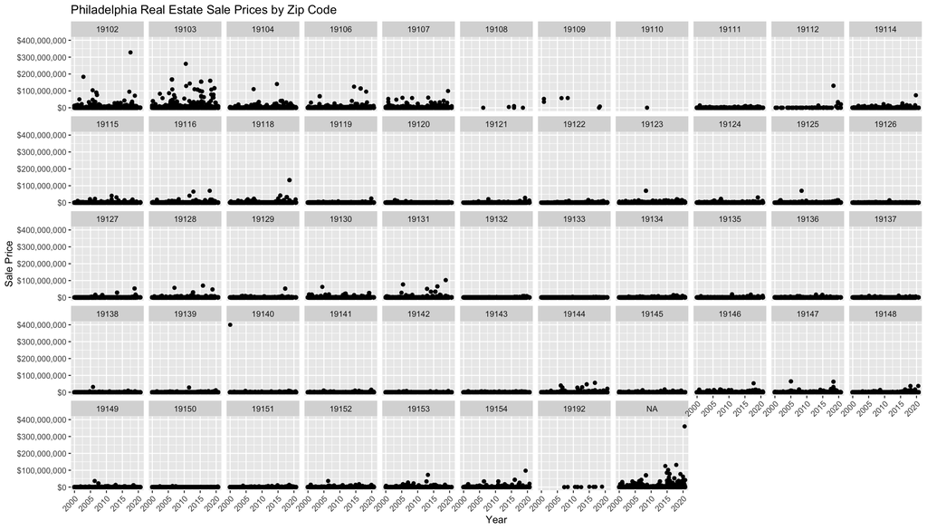

## 19121 Deep Dive

Let’s take a closer look at a single zip code. First some quick statistics

```r
# How do the Median Prices compare for all sales, and where an LLC is the buyer of the property?
# This was returning repeated "longer object length is not a multiple of shorter object length" error with LLC_identifier embedded, so I'll create a subset of LLC data first.
# deeds %>%
#   group_by(zip_code) %>%
#   summarise(median_price = median((cash_consideration / property_count), na.rm = TRUE),
#             # where grantee aka buyer is LLC
#             median_price_LLC_Buyer = median((cash_consideration[LLC_identifier(grantees)] / property_count), na.rm = TRUE),
#             # where grantor aka seller is LLC
#             median_price_LLC_Seller = median((cash_consideration[LLC_identifier(grantors)] / property_count), na.rm = TRUE))

# This has previously worked when I had left off the calculations for property_count, so it returned results results per deed (which may include multiple properties)
# The error is now being returned though using multiple groups with summarise(), "`summarise()` ungrouping output (override with `.groups` argument)"
# I've tried adding a .groups = 'keep' but this doesn't seem to remove the error, and the table is no longer appearing as a result
# commented out; requires more debugging
# deeds %>%
#   group_by(zip_code, grantees_entity_type) %>%
#   summarise(median_price = median(cash_consideration, na.rm = TRUE, .groups = 'keep'),
#            # where grantee aka buyer is LLC
#              median_price_LLC_Buyer = median(cash_consideration[LLC_identifier(grantees)], na.rm = TRUE, .groups = 'keep'),
#            # where grantor aka seller is LLC
#             median_price_LLC_Seller = median(cash_consideration[LLC_identifier(grantors)], na.rm = TRUE, .groups = 'keep'))
```

```r
# First let's collapse our per property calculations into named variables adjusted for our analysis.

# mutate runs and shows result, but I'm not seeing it in the variable list columns. Remember that mutate() – like all of the dplyr functions – strictly operates on dataframes. It’s not set up to work with lists, matrices, vectors, or other data structures.
# mutate(deeds, calc_sales_price = deeds$cash_consideration / deeds$property_count)
deeds$calc_sales_price <- deeds$cash_consideration / deeds$property_count
# mutate(deeds, calc_FMV = deeds$fair_market_value / deeds$property_count)
deeds$calc_FMV <- deeds$fair_market_value / deeds$property_count
```

```r
# Apply filter using LLC_identifier function to deeds
deeds_LLC <- filter(deeds,
                    LLC_identifier(deeds$grantees))


summary(deeds_LLC)
```

```
##     objectid         document_id       document_type       display_date        street_address        zip_code          ward        grantors           grantees         cash_consideration
##  Min.   : 7741295   Min.   :50000109   Length:96508       Min.   :1920-09-10   Length:96508       Min.   :19102   Min.   : 1.0   Length:96508       Length:96508       Min.   :        0
##  1st Qu.: 9471209   1st Qu.:52118165   Class :character   1st Qu.:2009-07-20   Class :character   1st Qu.:19123   1st Qu.:15.0   Class :character   Class :character   1st Qu.:    17000
##  Median :10271398   Median :52916326   Mode  :character   Median :2015-04-20   Mode  :character   Median :19134   Median :31.0   Mode  :character   Mode  :character   Median :    55684
##  Mean   :10180371   Mean   :52626545                      Mean   :2013-08-05                      Mean   :19132   Mean   :29.5                                         Mean   :   531548
##  3rd Qu.:10745587   3rd Qu.:53334266                      3rd Qu.:2018-02-08                      3rd Qu.:19143   3rd Qu.:42.0                                         3rd Qu.:   185000
##  Max.   :11894612   Max.   :53710503                      Max.   :2020-08-25                      Max.   :19154   Max.   :66.0                                         Max.   :360000000
##                                                                                                   NA's   :6206    NA's   :326                                          NA's   :36
##  other_consideration total_consideration assessed_value      common_level_ratio fair_market_value   state_tax_amount  state_tax_percent local_tax_amount   local_tax_percent adjusted_cash_consideration
##  Min.   :       0    Min.   :        0   Min.   :        0   Min.   :  0.00     Min.   :        0   Min.   :      0   Min.   :  0.00    Min.   :       0   Min.   :  0.00    Min.   :        0
##  1st Qu.:       0    1st Qu.:    19536   1st Qu.:    22000   1st Qu.:  1.01     1st Qu.:    23296   1st Qu.:    250   1st Qu.:100.00    1st Qu.:     750   1st Qu.:100.00    1st Qu.:    15150
##  Median :       0    Median :    59000   Median :    72200   Median :  1.01     Median :    61164   Median :    650   Median :100.00    Median :    1961   Median :100.00    Median :    46600
##  Mean   :    9762    Mean   :   547820   Mean   :   594150   Mean   :  1.02     Mean   :   566849   Mean   :   5695   Mean   : 99.57    Mean   :   17604   Mean   : 99.77    Mean   :   232063
##  3rd Qu.:       0    3rd Qu.:   193500   3rd Qu.:   181000   3rd Qu.:  1.01     3rd Qu.:   165741   3rd Qu.:   2100   3rd Qu.:100.00    3rd Qu.:    6228   3rd Qu.:100.00    3rd Qu.:   120000
##  Max.   :44449990    Max.   :360000000   Max.   :247000000   Max.   :101.00     Max.   :251940000   Max.   :3600000   Max.   :100.00    Max.   :11800800   Max.   :100.00    Max.   :360000000
##  NA's   :26292       NA's   :1863        NA's   :28986       NA's   :52221      NA's   :1863        NA's   :1863      NA's   :2536      NA's   :1863       NA's   :2268      NA's   :1328
##  adjusted_other_consideration adjusted_total_consideration adjusted_assessed_value adjusted_fair_market_value adjusted_state_tax_amount adjusted_local_tax_amount receipt_num         receipt_date
##  Min.   :       0             Min.   :        0            Min.   :        0       Min.   :        0          Min.   :      0           Min.   :       0          Length:96508       Min.   :1999-12-06
##  1st Qu.:    3150             1st Qu.:    17000            1st Qu.:    18000       1st Qu.:    20608          1st Qu.:    270           1st Qu.:     825          Class :character   1st Qu.:2009-07-22
##  Median :    8390             Median :    48000            Median :    58500       Median :    49056          Median :    575           Median :    1770          Mode  :character   Median :2015-06-30
##  Mean   :  360458             Mean   :   236216            Mean   :   232006       Mean   :   215411          Mean   :   2643           Mean   :    8135                             Mean   :2013-09-27
```

[output cut: 27 more lines]

```r
glimpse(deeds_LLC)
```

```
## Rows: 96,508
## Columns: 50
## $ objectid                     <dbl> 7741295, 7744240, 7744718, 7744245, 7744247, 7744248, 7744249, 7744250, 7744260, 7744983, 7744344, 7745107, 7744648, 7744057, 7743589, 7743891, 7743894, 7743896, 7…
## $ document_id                  <dbl> 50941596, 50941890, 50942313, 50941895, 50941896, 50941896, 50941896, 50941896, 50941899, 50942546, 50941974, 50942655, 50942248, 50941738, 53393173, 50941595, 509…
## $ document_type                <chr> "DEED", "DEED", "DEED", "DEED", "DEED", "DEED", "DEED", "DEED", "DEED", "DEED", "DEED", "DEED", "DEED", "DEED", "DEED", "DEED", "DEED", "DEED", "DEED", "DEED", "DE…
## $ display_date                 <date> 2004-05-07, 2004-05-25, 2004-06-02, 2004-05-25, 2004-05-25, 2004-05-25, 2004-05-25, 2004-05-25, 2004-05-28, 2004-05-27, 2004-05-20, 2004-05-13, 2004-05-17, 2004-0…
## $ street_address               <chr> "", "833 BAINBRIDGE ST", "6634 GILLESPIE ST", "2217 S NORWOOD ST", "1663 S 16TH ST", "2237 WINTON ST", "2246 S NORWOOD ST", "2618 REED ST", "962 N LAWRENCE ST", "3…
## $ zip_code                     <dbl> NA, 19147, 19135, 19145, 19145, 19145, 19145, 19146, 19123, 19119, 19134, 19146, 19124, 19145, NA, 19145, 19146, 19148, 19151, 19124, 19104, 19134, 19103, 19103, 1…
## $ ward                         <dbl> NA, 2, 55, 48, 36, 48, 48, 36, 5, 9, 25, 30, 33, 48, NA, 48, 36, 39, 34, 35, 6, 33, 8, 8, 8, 8, 8, 8, 8, 61, 56, 38, 31, 51, 45, 2, 35, 16, 16, 45, 39, 24, 5, 46, …
## $ grantors                     <chr> "CRISTINZIO JOSEPH; ESPOSITO THOMAS", "PAINTER DEBRA LEE; PAINTER JOSEPH HARRY", "CROWTHERS WILLIAM D JR", "GARNET-NORWOOD LLC", "KD PROPERTIES LLC", "KD PROPERTIE…
## $ grantees                     <chr> "FIRST PENNSYLVANIA PROPERTIES LLC", "RK GOUP LLC", "WINDSOR ENTERPRISES II LLC", "SPRUCE PROPERTY MANAGEMENT LLC", "SPRUCE PROPERTY MANAGEMENT LLC", "SPRUCE PROPE…
## $ cash_consideration           <dbl> 40000.00, 175000.00, 70000.00, 45000.00, 180000.00, 180000.00, 180000.00, 180000.00, 400000.00, 125500.00, 22021.00, 121000.00, 46500.00, 77000.00, 4925000.00, 400…
## $ other_consideration          <dbl> 0, 0, NA, 0, 0, 0, 0, 0, 0, NA, 0, NA, NA, 0, 0, 0, 0, 0, NA, NA, 0, NA, NA, NA, NA, NA, NA, NA, NA, 0, 0, 0, NA, NA, NA, NA, NA, 0, 0, NA, NA, NA, NA, NA, 0, NA, …
## $ total_consideration          <dbl> 40000.00, 175000.00, 70000.00, 45000.00, 180000.00, 180000.00, 180000.00, 180000.00, 400000.00, 125500.00, 22021.00, 121000.00, 46500.00, 77000.00, 4925000.00, 400…
## $ assessed_value               <dbl> NA, NA, NA, NA, NA, NA, NA, NA, NA, NA, NA, NA, NA, NA, 0, NA, NA, NA, NA, NA, NA, NA, NA, NA, NA, NA, NA, NA, NA, NA, NA, NA, NA, NA, NA, NA, NA, NA, NA, NA, NA, …
```

[output cut: 37 more lines]

```r
# See just a list of the grantees to validate the LLC filter results.
list(deeds_LLC$grantees)
```

```
## [[1]]
##    [1] "FIRST PENNSYLVANIA PROPERTIES LLC"                                                     "RK GOUP LLC"
##    [3] "WINDSOR ENTERPRISES II LLC"                                                            "SPRUCE PROPERTY MANAGEMENT LLC"
##    [5] "SPRUCE PROPERTY MANAGEMENT LLC"                                                        "SPRUCE PROPERTY MANAGEMENT LLC"
##    [7] "SPRUCE PROPERTY MANAGEMENT LLC"                                                        "SPRUCE PROPERTY MANAGEMENT LLC"
##    [9] "RGV BUILDER LLC"                                                                       "LJR INVESTMENTS LLC"
##   [11] "BLUELINE INVESTMENT GROUP LLC"                                                         "BELLWEATHER RENTALS LLC"
##   [13] "AJR RENTALS LLC"                                                                       "JXJ HOLDINGS LLC"
##   [15] "BHB GROUP INVESTMENT LIMITED LIABILTY COMPANY"                                         "FIRST PENNSYLVANIA PROPERTIES LLC"
##   [17] "FIRST PENNSYLVANIA PROPERTIES LLC"                                                     "FIRST PENNSYLVANIA PROPERTIES LLC"
##   [19] "ALDWIN GROUP LLC"                                                                      "BLV PROPERTY MANAGEMENT LLC"
##   [21] "EAST COAST CAPITAL COMPANY LIMITED"                                                    "BUENA VISTA HOLDINGS LLC"
##   [23] "1700 PINE STREET PROPERTIES LLC"                                                       "1700 PINE STREET PROPERTIES LLC"
##   [25] "1700 PINE STREET PROPERTIES LLC"                                                       "1700 PINE STREET PROPERTIES LLC"
##   [27] "1700 PINE STREET PROPERTIES LLC"                                                       "1700 PINE STREET PROPERTIES LLC"
```

[output cut: 487 more lines]

```r
# Add a column to Deeds to append LLC Ownership; to allow for showing a table view of filtered columns within one data table (as alternative to applying LLC_identifier within script repeatedly).
deeds$grantees_entity_type <- LLC_identifier(deeds$grantees)

# rewrite it with subsets; still requires debugging, maybe try mutate() to add each mean, median as column
# deeds.table_19121 <- deeds %>%
#   group_by(zip_code, grantees_entity_type) %>%
#   summarise(median((cash_consideration / property_count), na.rm = TRUE),
#           mean((cash_consideration / property_count), na.rm = TRUE)
#           )


# Note the $10 median price in 19108; this is a city block zip code with 0 population what contains Netrality Data Centers/ Sungard Availability Services
# Similarly, 19109 is a single city block containing several large office buildings in Center City and which is over a SEPTA subway transit concourse area.

# Now look only at 19121 in lower North Philadelphia; incl. Strawberry Mansion, Brewerytown, Francisville neighborhood areas.

deeds_19121 <- filter(deeds, zip_code == "19121")
summary(deeds_19121)
```

```
##     objectid         document_id       document_type       display_date        street_address        zip_code          ward        grantors           grantees         cash_consideration
##  Min.   : 7744368   Min.   :50000330   Length:21446       Min.   :1922-02-19   Length:21446       Min.   :19121   Min.   :16.0   Length:21446       Length:21446       Min.   :       0
##  1st Qu.: 8915019   1st Qu.:51419649   Class :character   1st Qu.:2006-02-10   Class :character   1st Qu.:19121   1st Qu.:29.0   Class :character   Class :character   1st Qu.:       1
##  Median : 9884932   Median :52307391   Mode  :character   Median :2010-12-07   Mode  :character   Median :19121   Median :32.0   Mode  :character   Mode  :character   Median :   12500
##  Mean   : 9812573   Mean   :52185186                      Mean   :2010-12-11                      Mean   :19121   Mean   :34.4                                         Mean   :  116287
##  3rd Qu.:10612027   3rd Qu.:53095013                      3rd Qu.:2016-06-30                      3rd Qu.:19121   3rd Qu.:32.0                                         3rd Qu.:   82500
##  Max.   :11894742   Max.   :53710638                      Max.   :2020-08-26                      Max.   :19121   Max.   :47.0                                         Max.   :28141500
##                                                                                                                                                                        NA's   :7
##  other_consideration total_consideration assessed_value     common_level_ratio fair_market_value  state_tax_amount   state_tax_percent local_tax_amount local_tax_percent adjusted_cash_consideration
##  Min.   :     0      Min.   :       0    Min.   :       0   Min.   :1.000      Min.   :       0   Min.   :     0.0   Min.   :  0.00    Min.   :     0   Min.   :  0.00    Min.   :       0
##  1st Qu.:     0      1st Qu.:       1    1st Qu.:    5280   1st Qu.:1.010      1st Qu.:    5819   1st Qu.:     0.0   1st Qu.:100.00    1st Qu.:     0   1st Qu.:100.00    1st Qu.:       1
##  Median :     0      Median :   15000    Median :   26300   Median :1.010      Median :   12958   Median :   223.2   Median :100.00    Median :   434   Median :100.00    Median :   12150
##  Mean   :   200      Mean   :  119517    Mean   :  152174   Mean   :1.014      Mean   :   97879   Mean   :  1298.7   Mean   : 99.18    Mean   :  3642   Mean   : 99.07    Mean   :   72448
##  3rd Qu.:     0      3rd Qu.:   85000    3rd Qu.:   76100   3rd Qu.:1.020      3rd Qu.:   44811   3rd Qu.:   990.0   3rd Qu.:100.00    3rd Qu.:  2490   3rd Qu.:100.00    3rd Qu.:   70000
##  Max.   :117916      Max.   :28141500    Max.   :29517149   Max.   :1.060      Max.   :29812320   Max.   :281415.0   Max.   :100.00    Max.   :922478   Max.   :100.00    Max.   :14070750
##  NA's   :8813        NA's   :558         NA's   :10461      NA's   :15234      NA's   :558        NA's   :558        NA's   :729       NA's   :558      NA's   :1610      NA's   :519
##  adjusted_other_consideration adjusted_total_consideration adjusted_assessed_value adjusted_fair_market_value adjusted_state_tax_amount adjusted_local_tax_amount receipt_num         receipt_date
##  Min.   :     0.5             Min.   :       0             Min.   :       1        Min.   :       1           Min.   :     0.33         Min.   :     1            Length:21446       Min.   :1999-12-06
##  1st Qu.:  2496.5             1st Qu.:       1             1st Qu.:    4864        1st Qu.:    5424           1st Qu.:   100.00         1st Qu.:   333            Class :character   1st Qu.:2006-03-07
##  Median :  4657.0             Median :   13200             Median :   21800        Median :   11555           Median :   360.00         Median :  1151            Mode  :character   Median :2010-11-30
##  Mean   :  9159.1             Mean   :   73547             Mean   :   69977        Mean   :   45560           Mean   :   996.38         Mean   :  3249                               Mean   :2011-01-23
##  3rd Qu.: 10210.0             3rd Qu.:   70000             3rd Qu.:   57532        3rd Qu.:   31001           3rd Qu.:  1049.75         3rd Qu.:  3442                               3rd Qu.:2016-09-20
##  Max.   :117916.0             Max.   :14070750             Max.   :14758574        Max.   :14906160           Max.   :140707.50         Max.   :461239                               Max.   :2020-08-31
##  NA's   :21211                NA's   :840                  NA's   :10848           NA's   :1585               NA's   :5912              NA's   :7354                                 NA's   :558
##  recording_date       document_date         condo_name          unit_num          address_low    address_low_suffix address_low_frac    address_high   street_predir      street_name
##  Min.   :1999-12-06   Min.   :1922-02-19   Length:21446       Length:21446       Min.   :    1   Length:21446       Length:21446       Min.   : 2.0    Length:21446       Length:21446
##  1st Qu.:2006-04-17   1st Qu.:2006-02-23   Class :character   Class :character   1st Qu.: 1601   Class :character   Class :character   1st Qu.:15.0    Class :character   Class :character
##  Median :2011-01-21   Median :2010-12-17   Mode  :character   Mode  :character   Median : 1829   Mode  :character   Mode  :character   Median :26.0    Mode  :character   Mode  :character
##  Mean   :2011-02-11   Mean   :2010-12-19                                         Mean   : 1951                                         Mean   :27.3
##  3rd Qu.:2016-08-05   3rd Qu.:2016-06-30                                         3rd Qu.: 2149                                         3rd Qu.:38.0
##  Max.   :2020-08-31   Max.   :2020-08-26                                         Max.   :11898                                         Max.   :78.0
##                       NA's   :194                                                NA's   :5                                             NA's   :20374
```

[output cut: 16 more lines]

```r
glimpse(deeds_19121)
```

```
## Rows: 21,446
## Columns: 51
## $ objectid                     <dbl> 7745097, 7744368, 7744649, 7746713, 7745905, 7745195, 7748459, 7747993, 7748552, 7747362, 7750089, 7750090, 7750135, 7749935, 7749964, 7749965, 7749709, 7751801, 7…
## $ document_id                  <dbl> 50942646, 50092336, 50942249, 50944139, 50943374, 50942725, 50945662, 50945239, 50092723, 50944722, 50946968, 50946969, 50947000, 50946846, 50946864, 50946865, 509…
## $ document_type                <chr> "DEED", "DEED", "DEED", "DEED", "DEED", "DEED", "DEED", "DEED", "DEED", "DEED", "DEED", "DEED", "DEED", "DEED", "DEED", "DEED", "DEED", "DEED", "DEED", "DEED", "DE…
## $ display_date                 <date> 2002-06-05, 2000-05-30, 2004-06-03, 2004-05-27, 2003-12-16, 2004-06-04, 2002-02-15, 2004-06-04, 1994-02-10, 2004-05-20, 2004-04-20, 2004-06-07, 2004-06-14, 2004-0…
## $ street_address               <chr> "2231 FONTAIN ST", "1529 PAGE ST", "1727 N BOUVIER ST", "1453 N 30TH ST", "1533 N 33RD ST", "1618 N 29TH ST", "1854 N MARSTON ST", "1708 JEFFERSON ST", "2126 N 32N…
## $ zip_code                     <dbl> 19121, 19121, 19121, 19121, 19121, 19121, 19121, 19121, 19121, 19121, 19121, 19121, 19121, 19121, 19121, 19121, 19121, 19121, 19121, 19121, 19121, 19121, 19121, 19…
## $ ward                         <dbl> 32, 32, 47, 29, 29, 32, 32, 47, 32, 32, 29, 29, 47, 32, 29, 29, 32, 29, 29, 29, 32, 47, 29, 29, 47, 32, 29, 47, 47, 47, 32, 32, 32, 29, 32, 29, 29, 29, 32, 29, 29,…
## $ grantors                     <chr> "DEANS JOHNNIE", "MOORE DAVID E", "CBM HOMEOWNERSHIP DEVELOPMENT CORPORATION INC", "WILSON LARRY; WILSON RUTHER MAE", "JONES AVERY; JONES DIRRICK; JONES WILLIE M; …
## $ grantees                     <chr> "DEANS DARNELL M JR; DEANS DARNELL M SR", "WASHINGTON HENRY A", "GRIER ANTHONY; SEARS SHERRY", "DISSIN PETER; FUIMAN SCOTT", "LONG CHRISTOPHER", "DONG XIU LIN; LIN…
## $ cash_consideration           <dbl> 1, 31000, 41500, 22000, 10000, 35000, 1, 48000, 1, 36000, 1, 10000, 10, 22200, 0, 0, 9000, 62000, 1, 1, 5000, 1, 3000, 27000, 17500, 1, 43000, 1, 1, 1, 1, 1, 1, 1,…
## $ other_consideration          <dbl> NA, NA, NA, NA, NA, NA, NA, 0, 0, NA, NA, NA, 0, 0, NA, NA, 0, NA, NA, NA, NA, NA, NA, NA, 0, 0, 0, NA, NA, NA, NA, NA, NA, NA, 0, NA, NA, 0, NA, NA, NA, NA, NA, N…
## $ total_consideration          <dbl> 1, 31000, 41500, 22000, 10000, 35000, 1, 48000, 1, 36000, 1, 10000, 10, 22200, 0, 0, 9000, 62000, 1, 1, 5000, 1, 3000, 27000, 17500, 1, 43000, 1, 1, 1, 1, 1, 1, 1,…
## $ assessed_value               <dbl> NA, NA, NA, NA, NA, NA, NA, NA, NA, NA, NA, NA, NA, NA, NA, NA, NA, NA, NA, NA, NA, NA, NA, NA, NA, NA, NA, NA, NA, NA, NA, NA, NA, NA, NA, NA, NA, NA, NA, NA, NA,…
```

[output cut: 38 more lines]

```r
median(deeds_19121$cash_consideration / deeds_19121$property_count, na.rm = TRUE) # median price in 19121 with 7 nulls removed is $10,000
```

```
## [1] 10000
```

```r
# 5,870 LLC buyers deeds, and 15,576 other entity type buyers deeds in 19121
```

# Plot Sales History in 19121

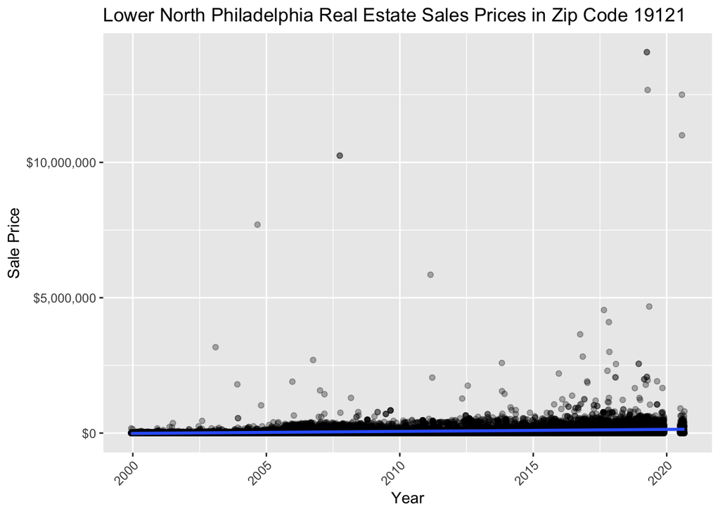

### Litigation

The common liability risk of property ownership is the notorious slip and fall claim of negligence, more officially known as “Premise Liability”. Not limited to rental tenants, anyone walking on the sidewalk in front of a city property can claim negligence. It is generally reported that most slip or trip and fall accident cases of negligence are settled out of court and with insurance agencies acting on behalf of LLC/property owners. As a property owner myself, I personally can share that I have settled a slip and fall incident out of court due to the expense and time that defending in court would require, so I do believe this generalization to be valid. Legal settlements data are not public record however, although it has been argued widely that they should be for public transparency.

Legal cases decided by a judge or jury do become public record however, which could contain a limited number of relevent records. I attempted to source enough civil lawsuit cases to analyze liability, identifying e.g. fines, costs and restitutions. Unfortunately however, I’ve found that there is no organized data structure this is available in, and it is exclusively in document pdf formats in Philadelphia’s court websites. Documents (docketed statements and summaries) are searchable by limited search fields, or listed as as a limited number of most recent cases. source: https://www.ncsc.org/topics/access-and-fairness/privacy-public-access-to-court-records/state-links3#Pennsylvania

I reviewed the published statistics available, but there was insufficient information available there to tie even # of cases to LLC defendents. Wildcard searches 3,596 docketed cases of Premise Liability were recorded in PA in 2019, within the general Tort category second only to motor vehicle case type. source1: http://www.pacourts.us/assets/files/setting-7803/file-10537.pdf?cb=bb47d4 p.4 source: http://www.pacourts.us/news-and-statistics/research-and-statistics/

I searched Philadelphia’s Civil Court Cases, but encountered bugs in their website and was unable to advance from the first to second page of search results for a wildcard %LLC search which was somewhat successful in finding at least some results validated from page 1 that were slip and fall cases with LLC in the org name. The information that could be scraped from a table format in the page results was limited however and did not indicate the Case Type which would indicate Premise Liability, and in order to filter for that type, it would require clicking into individual result page summaries. source1: https://fjdefile.phila.gov/efsfjd/zk_fjd_public_qry_01.zp_personcase_details_idx source: https://www.courts.phila.gov/casesearch/

I managed to find a way to get a sizable amount of LLC search results for claims from The Philadelphia Courts First Judicial District of Pennsylvania. Organization Name = %LLC Case Type SC - Statement of Claims Upon detailed inspection of several results, understanding nature of claim requires opening initial claim transaction document attached to record, e.g. to see it’s owed rental security deposit, unpaid condo fees, etc. so the nature of the claim is not easy to distinguish in a readable structured data format.

To get a comparative dataset for claims outside LLC Defendents for same time period (or any), I ran a search with “%” wildcard character in the required on Name/Org Name field, and returned the max 10,000 values alotted in fjd’s html code for the search.do data source search results. source: https://fjdclaims.phila.gov/phmuni/cms/search.do

```r
#source()

#claim_statements <-

#summary(claim_statements)
```

### Property and Casualty Insurance

I searched for freely available insurance data and found a lead on statista.com, but some of their data access is paid by subscription: https://www.statista.com/topics/2832/property-and-casualty-insurance-in-the-united-states/ I cannot find another public dataset related to claims or insurance rates/coverage to tie to liability. Possibly certain commercial mortgage lenders may require certain levels of insurance, which may be a topic for further research.

## Objective 2 LLC Buyer Relationship to Market Rate

# Calculate Market Value

According to SFgate.com, " A property’s fair market value defines what you could expect to receive if you were to sell it privately that day… Divide the average sale price by the average square footage to calculate the average value of all properties per square foot. Multiply this amount by the number of square feet in your home for a very accurate estimate of the fair market value of your home. "

https://homeguides.sfgate.com/determine-fair-market-value-home-7935.html

(Note this is considered a fairly direct and traditional approach to appraising property, and does not take into account improvments or other factors that may adjust the value of a property. For our purposes though I like the simplicity of this calculation.)

According to Fannie Mae, here’s another definition in lay terms, " Market value is the most probable price that a property should bring in a competitive and open market under all conditions requisite to a fair sale, the buyer and seller, each acting prudently, knowledgeably and assuming the price is not affected by undue stimulus. "

```r
# Philadelphia city/county population of deeds 1999 to 2020
# Let's try this by median and mean for comparison
# Note there is a "fair_market_value" variable provided in the table, but I will calculate my own for analysis and learning purposes; can compare those later.

summary(deeds)
```

```
##     objectid         document_id       document_type       display_date        street_address        zip_code          ward         grantors           grantees         cash_consideration
##  Min.   : 7741116   Min.   :50000005   Length:842127      Min.   :1919-04-28   Length:842127      Min.   :19102   Min.   : 1.00   Length:842127      Length:842127      Min.   :        0
##  1st Qu.: 8793361   1st Qu.:51010617   Class :character   1st Qu.:2004-07-24   Class :character   1st Qu.:19123   1st Qu.:18.00   Class :character   Class :character   1st Qu.:        1
##  Median : 9857854   Median :51991314   Mode  :character   Median :2008-09-26   Mode  :character   Median :19134   Median :35.00   Mode  :character   Mode  :character   Median :    57000
##  Mean   : 9800421   Mean   :51943190                      Mean   :2009-09-06                      Mean   :19133   Mean   :33.31                                         Mean   :   203683
##  3rd Qu.:10735008   3rd Qu.:52926732                      3rd Qu.:2015-05-06                      3rd Qu.:19145   3rd Qu.:49.00                                         3rd Qu.:   162000
##  Max.   :11894742   Max.   :53710638                      Max.   :2020-08-28                      Max.   :19192   Max.   :66.00                                         Max.   :400003936
##                                                                                                   NA's   :28779   NA's   :2567                                          NA's   :384
##  other_consideration total_consideration assessed_value      common_level_ratio fair_market_value   state_tax_amount  state_tax_percent local_tax_amount   local_tax_percent adjusted_cash_consideration
##  Min.   :       0    Min.   :        0   Min.   :        0   Min.   :     0.0   Min.   :        0   Min.   :      0   Min.   :  0.00    Min.   :       0   Min.   :  0.00    Min.   :        0
##  1st Qu.:       0    1st Qu.:        1   1st Qu.:    18100   1st Qu.:     1.0   1st Qu.:    24516   1st Qu.:      0   1st Qu.:100.00    1st Qu.:       0   1st Qu.:100.00    1st Qu.:        1
##  Median :       0    Median :    60000   Median :    79100   Median :     1.0   Median :    50960   Median :    600   Median :100.00    Median :    1650   Median :100.00    Median :    55000
##  Mean   :    2215    Mean   :   209874   Mean   :   264677   Mean   :     3.6   Mean   :   224910   Mean   :   2122   Mean   : 99.33    Mean   :    6322   Mean   : 99.37    Mean   :   137212
##  3rd Qu.:       0    3rd Qu.:   165000   3rd Qu.:   170200   3rd Qu.:     1.0   3rd Qu.:   107161   3rd Qu.:   1650   3rd Qu.:100.00    3rd Qu.:    4917   3rd Qu.:100.00    3rd Qu.:   150000
##  Max.   :44449990    Max.   :400003936   Max.   :461700000   Max.   :222800.0   Max.   :980072800   Max.   :3600000   Max.   :200.00    Max.   :11800800   Max.   :450.00    Max.   :400003936
##  NA's   :390454      NA's   :22857       NA's   :483175      NA's   :650863     NA's   :22854       NA's   :22852     NA's   :30884     NA's   :22852      NA's   :35821     NA's   :18521
##  adjusted_other_consideration adjusted_total_consideration adjusted_assessed_value adjusted_fair_market_value adjusted_state_tax_amount adjusted_local_tax_amount receipt_num         receipt_date
##  Min.   :       0             Min.   :        0            Min.   :        0       Min.   :        0          Min.   :      0           Min.   :       0          Length:842127      Min.   :1999-12-06
##  1st Qu.:    2000             1st Qu.:        1            1st Qu.:    18208       1st Qu.:    24509          1st Qu.:    395           1st Qu.:    1200          Class :character   1st Qu.:2004-08-03
##  Median :    5081             Median :    55250            Median :    71900       Median :    48985          Median :    910           Median :    2842          Mode  :character   Median :2008-07-22
##  Mean   :  109262             Mean   :   139090            Mean   :   160368       Mean   :   124855          Mean   :   1845           Mean   :    5677                             Mean   :2009-09-28
```

[output cut: 27 more lines]

```r
glimpse(deeds)
```

```
## Rows: 842,127
## Columns: 51
## $ objectid                     <dbl> 7741116, 7741117, 7741398, 7741283, 7741287, 7741295, 7741298, 7741470, 7741495, 7741673, 7741690, 7741698, 7741744, 7741981, 7742301, 7742244, 7742416, 7742856, 7…
## $ document_id                  <dbl> 50128982, 50128987, 51075355, 50791375, 50853599, 50941596, 50991684, 51104991, 51114994, 51254176, 51262428, 51263991, 51306554, 51511081, 51812249, 51761663, 518…
## $ document_type                <chr> "DEED", "DEED", "DEED", "DEED", "DEED", "DEED", "DEED", "DEED", "DEED", "DEED", "DEED", "DEED", "DEED", "DEED", "DEED", "DEED", "DEED", "DEED", "DEED", "DEED", "DE…
## $ display_date                 <date> 2000-08-25, 2000-08-25, 2004-12-07, 2003-10-10, 2004-01-21, 2004-05-07, 2004-08-02, 2005-01-03, 2005-01-20, 2005-03-08, 2005-08-29, 2005-09-08, 2005-11-01, 2006-0…
## $ street_address               <chr> "", "", "", "", "", "", "", "", "", "", "", "", "", "", "", "", "", "", "", "1535 S BROAD ST", "3083 MEMPHIS ST", "1221 HERBERT ST", "3631 AVALON ST", "3430 ALDINE…
## $ zip_code                     <dbl> NA, NA, NA, NA, NA, NA, NA, NA, NA, NA, NA, NA, NA, NA, NA, NA, NA, NA, NA, 19147, 19134, 19124, 19114, 19136, 19149, 19111, 19111, 19145, 19143, 19148, 19147, 191…
## $ ward                         <dbl> NA, NA, NA, NA, NA, NA, NA, NA, NA, NA, NA, NA, NA, NA, NA, NA, NA, NA, NA, 1, 25, 23, 66, 64, 62, 56, 56, 48, 40, 39, 2, 2, 11, 11, 56, 26, 46, 23, 58, 35, 35, 54…
## $ grantors                     <chr> "MISSING DOCUMENT", "MISSING DOCUMENT", "PHILADELPHIA AUTHORITY FOR INDUSTRIAL DEVELOPMENT", "DEL VALLE PENNYS M", "COMMONWEALTH OF PENNSYLVANIA", "CRISTINZIO JOSE…
## $ grantees                     <chr> "MISSING DOCUMENT", "MISSING DOCUMENT", "PIDC FINANCING CORPORATION", "DEJESUS NAZARIO", "BEACH STREET CORP", "FIRST PENNSYLVANIA PROPERTIES LLC", "FRANK STEPHANIE…
## $ cash_consideration           <dbl> 1.00, 1.00, 33600.00, 50000.00, 71150.00, 40000.00, 0.00, 1.00, 1.00, 27000.00, 160000.00, 1.00, 1.00, 1.00, 10.00, 500.00, 20000.00, 0.00, 1.00, 1.00, 58900.00, 1…
## $ other_consideration          <dbl> NA, NA, NA, NA, 0, 0, NA, NA, 0, 0, NA, NA, NA, 0, 0, NA, NA, 0, NA, NA, NA, NA, 0, NA, NA, NA, NA, NA, 0, 0, 0, 0, NA, NA, NA, NA, NA, NA, NA, NA, NA, NA, NA, NA,…
## $ total_consideration          <dbl> 1.00, 1.00, 33600.00, 50000.00, 71150.00, 40000.00, 0.00, 1.00, 1.00, 27000.00, 160000.00, 1.00, 1.00, 1.00, 10.00, 500.00, 20000.00, NA, 1.00, 1.00, 58900.00, 1.0…
## $ assessed_value               <dbl> NA, NA, NA, NA, NA, NA, NA, NA, NA, NA, NA, NA, NA, NA, NA, NA, NA, NA, 1440, NA, NA, NA, NA, NA, NA, NA, NA, NA, NA, NA, NA, NA, NA, NA, NA, NA, NA, NA, NA, NA, N…
```

[output cut: 38 more lines]

```r
# calculate the sum of missing values in deeds: 384 deeds with missing values
sum(is.na(deeds$cash_consideration))
```

```
## [1] 384
```

```r
# This still resulted in NA results for mean after running; replaced with na.rm = TRUE instead
# na.omit(deeds)

# calculate the mean sales price of the entire population of property transfers in Philly = $134,255 cash consideration per property
avg_sale_price_all_mean <- mean(deeds$cash_consideration / deeds$property_count, na.rm = TRUE)

# We'll use this as avaerage sale price: calculate the median sales price, generally considered to be more accurate to use in real estate valuation, of the entire population of property transfers in Philly = $50,816 cash consideration per property deed
avg_sale_price_all_med <- median(deeds$cash_consideration / deeds$property_count, na.rm = TRUE)

# mean sales for LLC grantees/buyers for all years is = $228,955
avg_sale_price_LLC_all_mean <- mean(deeds_LLC$cash_consideration / deeds_LLC$property_count, na.rm = TRUE)
# median sales for LLC grantees/buyers for all years is $45,000
avg_sale_price_LLC_all_med <- median(deeds_LLC$cash_consideration / deeds_LLC$property_count, na.rm = TRUE)
print(avg_sale_price_LLC_all_med)
```

```
## [1] 45000
```

```r
# Some other exploratory details
# how many deeds have $0 cash consideration? Result is 18,137 $0 deeds
sum(deeds$cash_consideration == 0, na.rm = TRUE)
```

```
## [1] 18137
```

```r
# how frequentlyis $1 the sale price as considered common practice to transfer between family members 'on the books' for free; result is 220,784 deeds
sum(deeds$cash_consideration == 1, na.rm = TRUE)
```

```
## [1] 220784
```

```r
sum(deeds_LLC$cash_consideration == 1, na.rm = TRUE) # result is $1 sales only occur 13,198 time with LLC buyers, presumably for associated entities transferring deed for liability protection, i.e. owners of the LLC
```

```
## [1] 13198
```

```r
# It is much less frequent for LLC to be transferred a deed for $1 than the overall population.

# consider for later possibility of removing $0 transaction records, but keep since these are common in real estate deeds.

# see frequency of each distinct sale price; this would be better built to view as counts by sale price ranges later
table(deeds$cash_consideration)
```

```
##
##       0    0.01    0.08       1    1.01     1.5       2       3       4       5       6       7       8       9      10      11      12      13      14      15      16      17      18      19      20
##   18137       2       1  220784       1       1     148      86      52     137      50      44      39      56    8147      43      58      67      54      15      48      17       3      48      65
##      21      22      23      24      25      26      27      28      29      30      31      35      36      37      38      39      41      43      50   54.68      56    69.1   81.93   97.01     100
##       7      47      23      25      39      26      30      28      58      38      33      49      37      37      41       9       2      38      16       1       1       1       1       1     459
##     101     104     105     107   110.2   116.7   117.9  122.05   123.2     125     134     143     150     166     194     200     201  202.39     207     225   232.7   233.5   235.9   240.6   246.4
##       1       1       1       1       1       1       1       1       3       1      36       2       3       3       1      65       1       1       1       1       1       1       1       2       1
##     250     252     266     272     300     320     350  351.24     400  400.64  412.87     425     450   472.5   486.6   489.6     500   500.8     501     510     520     550     556  560.03     562
##      29       3       1       1      46       7       3       1      33       1       1       1       8       1       1       7    1043       2       1       1       1       8       1       2       2
##     563     576  587.52     600  600.96     601     625     630     650     651  651.04     666     667  667.65     675     680     700     702  702.72     736     750     751     759     770  798.54
##       3       1       1      58       2       2       1       1       4       2       1       1       1       1       1       1      55       1       1       1      31       1       1       1       1
##     800   825.4     827  835.48     840     850     863     874     875   884.8     900  901.44     906   908.8  921.15     950     960     975  975.67     976   979.2  983.58     990    1000    1001
##     102       2       1       1       1       2       1       1       3       4      54       1       1       1       2       2       1       1       1       1       8       1       1    2701       1
##  1001.6    1011 1013.02    1020    1025 1028.22    1040    1050    1056    1062 1077.12 1083.97    1090    1096  1097.6    1100 1101.76    1107    1120    1126    1138 1142.78 1143.66    1150 1150.24
##       7       1       1       1       1       1       1       3       1       1       4       1       1       1       1      39       1       1       4       5       2       1       1       2       1
```

[output cut: 67 more lines]

```r
# Another factor is that some deeds have multiple properties included (see property_count). Bundling may result in a lower price situation per property with adjoined properties sold together.
# Median is 1 and mean of property count is 1.893014 with NA removed.
# For all of the FMV and price calculations that follow, I've divided by the property count on the deed to result is per property, not per deed, results.
median(deeds$property_count, na.rm = TRUE)
```

```
## [1] 1
```

```r
mean(deeds$property_count, na.rm = TRUE)
```

```
## [1] 1.893014
```

```r
max(deeds$property_count, na.rm = TRUE) # max for all properties is 202; same as LLC table
```

```
## [1] 202
```

```r
min(deeds$property_count, na.rm = TRUE) # 1, no zero values, with NA removed
```

```
## [1] 1
```

```r
# and for LLC property count:
median(deeds_LLC$property_count, na.rm = TRUE) # median for LLC is 1
```

```
## [1] 1
```

```r
mean(deeds_LLC$property_count, na.rm = TRUE) # mean for LLC is 3.843236, indicating some LLC deeds with higher numbers of properties included in sale
```

```
## [1] 3.843236
```

```r
max(deeds_LLC$property_count, na.rm = TRUE) # max for LLC properties is 202
```

```
## [1] 202
```

```r
# square footage is not available in this dataset, and requires linking to Office of Property Assessment records; an OPA_account number exists in this table, but has nulls, and so for now I will use the given fair_market_value in the table to test hypothesis

## LLC buyer entity FMV
# mean fair market value for LLC grantees/buyers $206,250
avg_fmv_LLC_all_mean <- mean((deeds_LLC$fair_market_value / deeds_LLC$property_count), na.rm = TRUE)
print(avg_fmv_LLC_all_mean)
```

```
## [1] 206250.2
```

```r
# median sales for LLC = $45,414
avg_fmv_LLC_all_med <- median((deeds_LLC$fair_market_value / deeds_LLC$property_count), na.rm = TRUE)
print(avg_fmv_LLC_all_med)
```

```
## [1] 45413.76
```

```r
## All Other buyer entities FMV = $108,665
# mean fair market value for LLC grantees/buyers
avg_fmv_other_all_mean <- mean((deeds_other$fair_market_value / deeds_other$property_count), na.rm = TRUE)
print(avg_fmv_other_all_mean)
```

```
## [1] 108664.8
```

```r
# median sales for all non-LLC buyer entities (includes partnership types, corporations and individuals) = $46,789
avg_fmv_other_all_med <- median((deeds_other$fair_market_value / deeds_other$property_count), na.rm = TRUE)
print(avg_fmv_other_all_med)
```

```
## [1] 46789.12
```

```r
?label_dollar
```

```r
options(na.action = na.warn)
max(deeds_other$cash_consideration / deeds_other$property_count, na.rm = TRUE) # $400,003,936
```

```
## [1] 400003936
```

```r
max(deeds_other$cash_consideration, na.rm = TRUE)
```

```
## [1] 400003936
```

```r
# Check into the outlier with highest sales price;
# After a Google map search and street view, I can see it's a random small row home in an average neighborhood that is not anywhere near a remarkable value; indicates an error or something else strange.
deeds %>% filter(cash_consideration == 400003936)

# Check into the outlier with highest FMV
# After a Google map search it's clear the sale price is for unit 118 in a senior community, and the FMV listed is actually for the entire housing property which is large and on the Delaware riverfront with many units.
max(deeds_other$fair_market_value / deeds_other$property_count, na.rm = TRUE) # $980,072,800
```

```
## [1] 980072800
```

```r
deeds %>% filter(fair_market_value == 980072800)
```

# Let’s plot FMV and Sales Price to see how they’re related

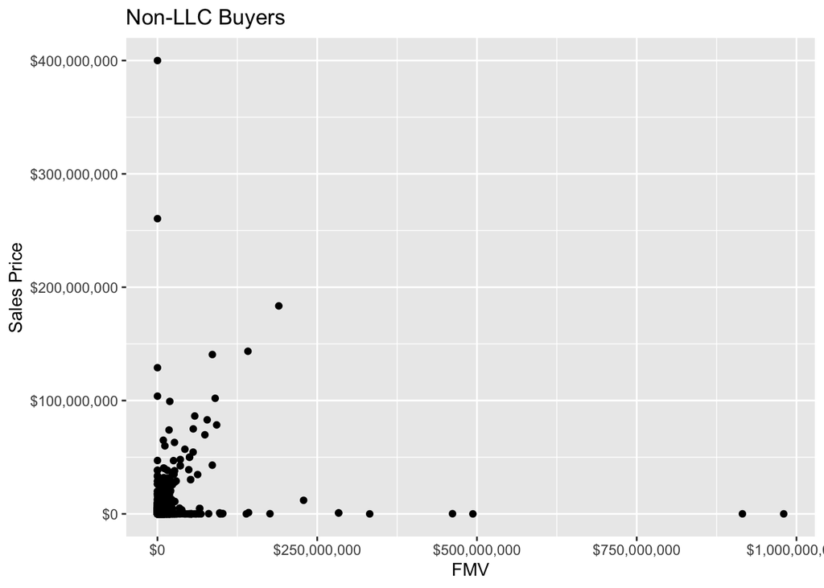

```r
plot_NonLLC_Buyers <- ggplot(deeds_other, aes(x = deeds_other$calc_FMV, y = deeds_other$calc_sales_price)) +
  geom_point() +
  ggtitle("Non-LLC Buyers") +
  scale_x_continuous(name = "FMV",labels = dollar) +
  scale_y_continuous(name = "Sales Price", labels = dollar)
print(plot_NonLLC_Buyers)
```

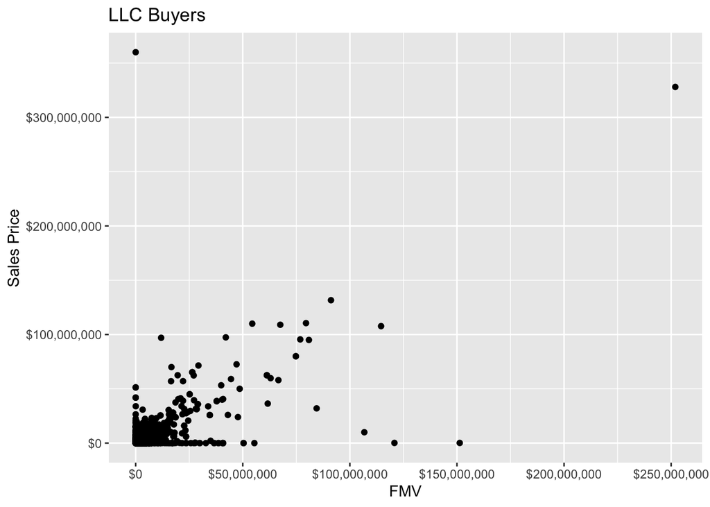

```r
plot_LLC_Buyers <- ggplot(deeds_LLC, aes(x = deeds_LLC$calc_FMV, y = deeds_LLC$calc_sales_price)) +
  geom_point() +
  ggtitle("LLC Buyers") +
  scale_x_continuous(name = "FMV",labels = dollar) +
  scale_y_continuous(name = "Sales Price", labels = dollar)
print(plot_LLC_Buyers)
```

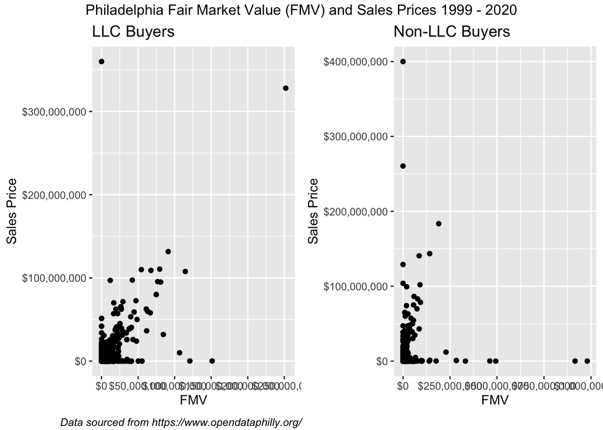

```r
# Place the two plots together horizontally

grid.arrange(
  plot_LLC_Buyers,
  plot_NonLLC_Buyers,
  nrow = 1,
  top = "Philadelphia Fair Market Value (FMV) and Sales Prices 1999 - 2020",
  bottom = textGrob(
    "Data sourced from https://www.opendataphilly.org/",
    gp = gpar(fontface = 3, fontsize = 9),
    hjust = 1,
    )
)
```

```r
?textGrob
```

## Identify the Outliers

Bivariate approach to finding outliers

```r
# Find the Outliers using a Bivariate approach with a box-plot
# For continuous variable (convert to categorical if needed.)
# boxplot(deeds$calc_FMV ~ deeds$calc_sales_price, data = deeds, main = "Boxplot for Sales Price (continuos var) vs FMV")
```

Univariate approach to finding outliers in Non-LLC Deeds

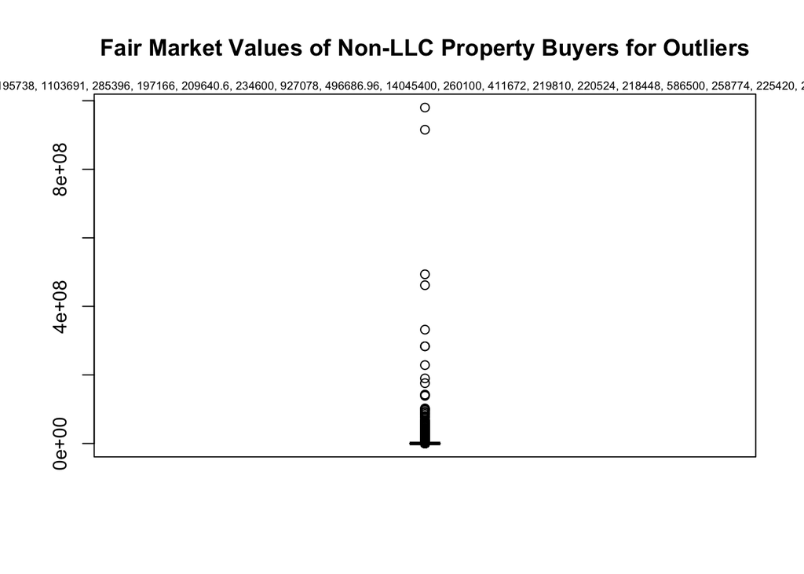

```r
# Identify outliers with a univariate approach: FMV calculated per property
deeds_other_outliers_FMV <- boxplot.stats(deeds_other$calc_FMV)$out  # outlier values.
boxplot(deeds_other$calc_FMV, main = "Fair Market Values of Non-LLC Property Buyers for Outliers", boxwex = 0.1)
mtext(paste("Outliers: ", paste(deeds_other_outliers_FMV, collapse = ", ")), cex = 0.6)
```

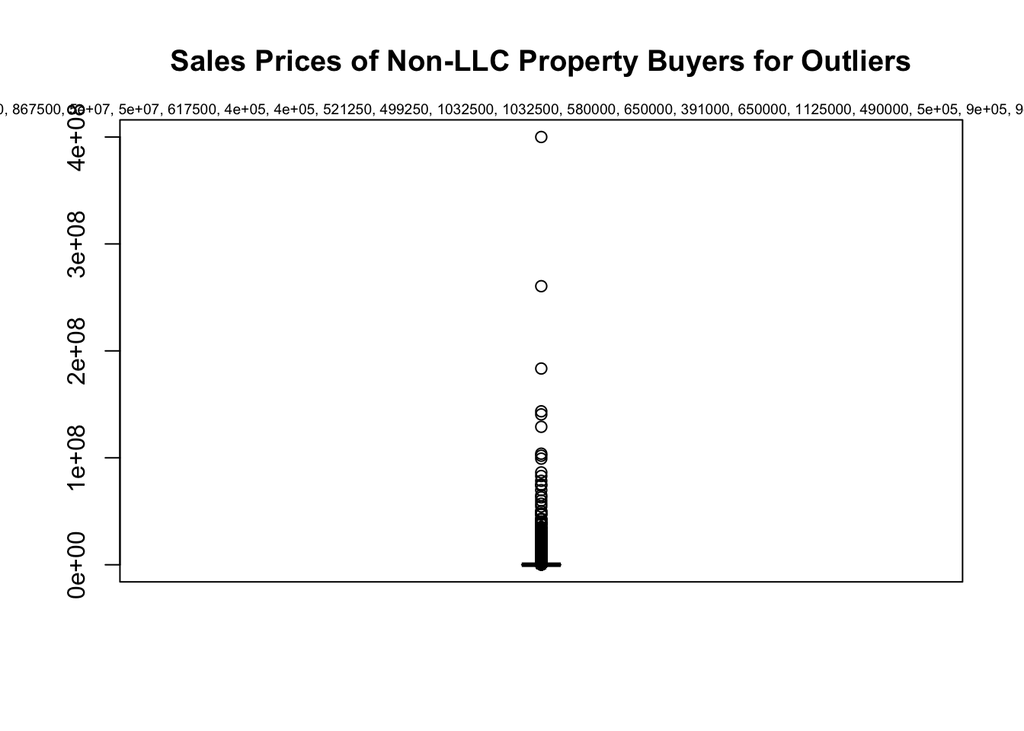

```r
# Identify outliers with a univariate approach: Sales Price calculated per property
deeds_other_outliers_Sales_Price <- boxplot.stats(deeds_other$calc_sales_price)$out  # outlier values.
boxplot(deeds_other$calc_sales_price, main = "Sales Prices of Non-LLC Property Buyers for Outliers", boxwex = 0.1)
mtext(paste("Outliers: ", paste(deeds_other_outliers_Sales_Price, collapse = ", ")), cex = 0.6)
```

Univariate approach to finding outliers in LLC Deeds

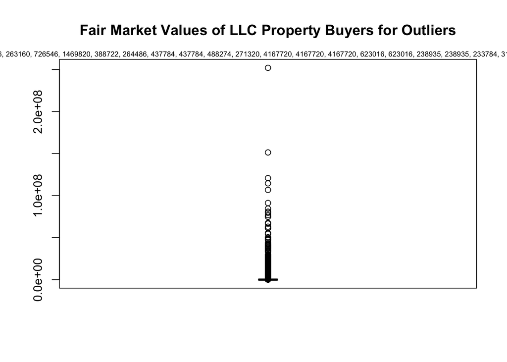

```r
# Identify outliers with a univariate approach: FMV calculated per property
deeds_LLC_outliers_FMV <- boxplot.stats(deeds_LLC$calc_FMV)$out  # outlier values.
boxplot(deeds_LLC$calc_FMV, main = "Fair Market Values of LLC Property Buyers for Outliers", boxwex = 0.1)
mtext(paste("Outliers: ", paste(deeds_LLC_outliers_FMV, collapse = ", ")), cex = 0.6)
```

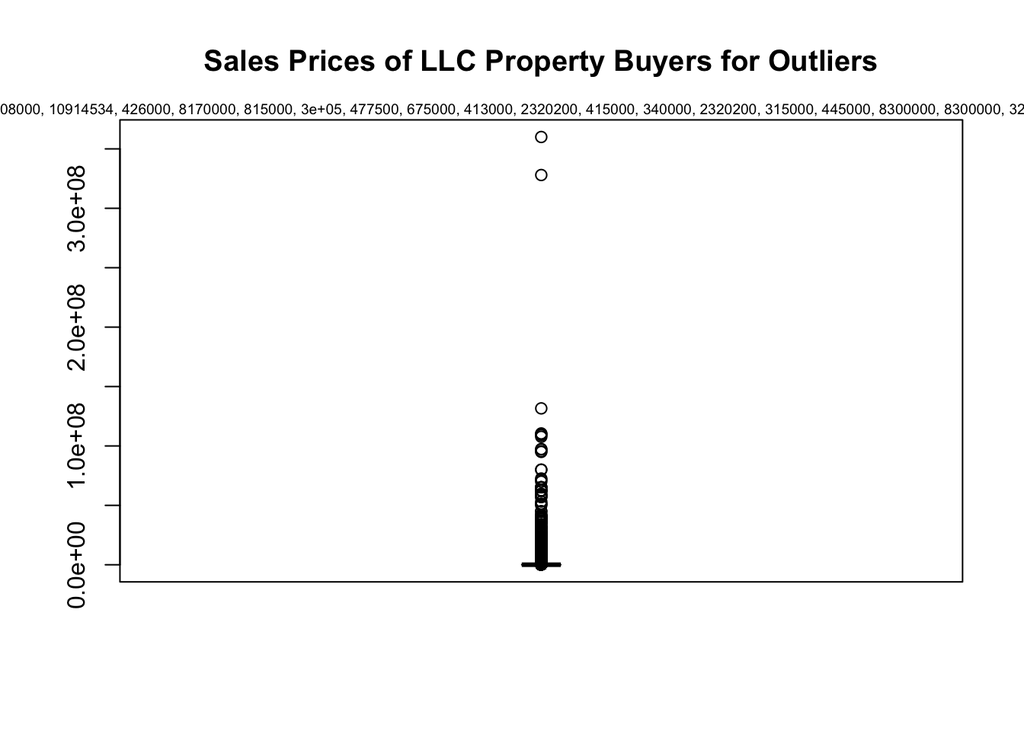

```r
# Identify outliers with a univariate approach: Sales Price calculated per property
deeds_LLC_outliers_Sales_Price <- boxplot.stats(deeds_LLC$calc_sales_price)$out  # outlier values.
boxplot(deeds_LLC$calc_sales_price, main = "Sales Prices of LLC Property Buyers for Outliers", boxwex = 0.1)
mtext(paste("Outliers: ", paste(deeds_LLC_outliers_Sales_Price, collapse = ", ")), cex = 0.6)
```

# Capping Outliers

For missing values that lie outside the 1.5 * IQR limits, we could cap it by replacing those observations outside the lower limit with the value of 5th %ile and those that lie above the upper limit, with the value of 95th %ile. Below is a sample code that achieves this.

source: http://r-statistics.co/Outlier-Treatment-With-R.html

```r
## Capping

# calc_FMV in deeds_other
x <- deeds_other$fair_market_value
qnt <- quantile(x, probs = c(.25, .75), na.rm = T)
caps <- quantile(x, probs = c(.05, .95), na.rm = T)
H <- 1.5 * IQR(x, na.rm = T)
x[x < (qnt[1] - H)] <- caps[1]
x[x > (qnt[2] + H)] <- caps[2]

# calc_sales_price  in deeds_other
x1 <- deeds_other$cash_consideration
qnt1 <- quantile(x1, probs = c(.25, .75), na.rm = T)
caps1 <- quantile(x1, probs = c(.05, .95), na.rm = T)
H1 <- 1.5 * IQR(x, na.rm = T)
x1[x1 < (qnt[1] - H)] <- caps[1]
x1[x1 > (qnt[2] + H)] <- caps[2]

# calc_FMV in deeds_LLC
x2 <- deeds_LLC$fair_market_value
qnt2 <- quantile(x2, probs = c(.25, .75), na.rm = T)
caps2 <- quantile(x2, probs = c(.05, .95), na.rm = T)
H2 <- 1.5 * IQR(x, na.rm = T)
x2[x2 < (qnt[1] - H)] <- caps[1]
x2[x2 > (qnt[2] + H)] <- caps[2]

# calc_sales_price  in deeds_LLC
x3 <- deeds_LLC$cash_consideration
qnt3 <- quantile(x3, probs = c(.25, .75), na.rm = T)
caps3 <- quantile(x3, probs = c(.05, .95), na.rm = T)
H3 <- 1.5 * IQR(x, na.rm = T)
x3[x3 < (qnt[1] - H)] <- caps[1]
x3[x3 > (qnt[2] + H)] <- caps[2]

# Let's refresh our calculated fields now.
deeds$calc_sales_price <- deeds$cash_consideration / deeds$property_count
deeds$calc_FMV <- deeds$fair_market_value / deeds$property_count
```

# Objective 2 Stretch Goal

Calculate a LTV loan to value percentage ratio and create its function. May need to use sale price or value in deed transaction for value if another value is not accessible.